# Course Project Machine Learning: Predict quality of barbell lifts

David Clijsters

Sunday, August 24, 2014

## Executive Summary

People regularly quantify how much of a particular activity they do, but they rarely quantify how well they do it. In this project, the goal will be to use data from accelerometers on the belt, forearm, arm, and dumbell of 6 participants to predict the quality of barbell lifts, classified in 5 different ways.

After data cleaning and exploration several models where tested with random forests as the best predicting (out of sample accuracy: 99.5%).

## Loading Data and Preprocessing

```r
#download and load training data
#FileTrain<-"https://d396qusza40orc.cloudfront.net/predmachlearn/pml-training.csv"
#download.file(FileTrain,"pml-training.csv",method="internal",mode="wb")
train<-read.csv("pml-training.csv")
# download and load testing data
#FileTest<-"https://d396qusza40orc.cloudfront.net/predmachlearn/pml-testing.csv"
#download.file(FileTest,"pml-testing.csv",method="internal",mode="wb")
test<-read.csv("pml-testing.csv",stringsAsFactors=FALSE)
data<-train[train$new_window=="no",]
data<-data[,-c(1:7)] # delete first 7 columns containing no features
tdc<-grep("kurtosis_",names(data))
tdc<-c(tdc,grep("skewness_",names(data)))
tdc<-c(tdc,grep("max_",names(data)))
tdc<-c(tdc,grep("min_",names(data)))
tdc<-c(tdc,grep("amplitude_",names(data)))
tdc<-c(tdc,grep("var_",names(data)))
tdc<-c(tdc,grep("avg_",names(data)))
tdc<-c(tdc,grep("stddev_",names(data)))
data<-data[,-tdc] # delete all columns that have statistics calculated
# apply same transformations on test
test<-test[,-c(1:7)]
test<-test[,-tdc]
```

From the initial training and test dataset several rows and columns were removed: * rows with new_window equal to ‘yes’ are removed since these rows seem to be aggregation rows collecting statistics of a window number * After deleting previous rows a lot of columns (containing the statistics) became obsolute and were removed too. * The first 7 rows contain data which are not relevant in the prediction (names, timestamps,…), so they are deleted too.

After all these actions the train set (now called data) is reduced from 160 to 53 columns and has 406 rows less.

The same transformations are executed on test.

## Exploratory Data Analysis

After the first cleaning a short graphical exploration of the data was done by plotting some variables and coloring them by classe (=outcome) to see if some patterns show up.

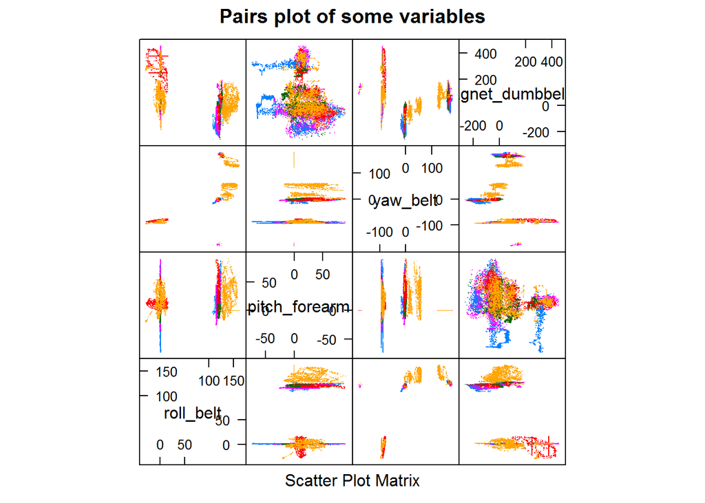

### Model selection and evaluation

Firstly the **data** are split into train (**dataTrain**) and test (**dataTest**) data to test the model accuracy (out of sample error). Cross-validation will be done for the different models based on this split.

We start with and easy to interpret model.

#### 1. Recursive Partitioning and Regression Trees (rpart)

```r
set.seed(1230)
inTrain<-createDataPartition(data$classe,p=0.7,list=FALSE)
dataTrain<-data[inTrain,]
dataTest<-data[-inTrain,]
# Prediction with the trees
modFit1<-train(classe~.,method="rpart",data=dataTrain)
print(modFit1$finalModel)
```

```
## n= 13453
##
## node), split, n, loss, yval, (yprob)
##       * denotes terminal node
##
##  1) root 13453 9623 A (0.28 0.19 0.17 0.16 0.18)
##    2) roll_belt< 130.5 12327 8506 A (0.31 0.21 0.19 0.18 0.11)
##      4) pitch_forearm< -26.45 1179   51 A (0.96 0.043 0 0 0) *
##      5) pitch_forearm>=-26.45 11148 8455 A (0.24 0.23 0.21 0.2 0.12)
##       10) magnet_dumbbell_y< 439.5 9429 6789 A (0.28 0.18 0.24 0.19 0.11)
##         20) roll_forearm< 120.5 5819 3448 A (0.41 0.18 0.19 0.17 0.063) *
##         21) roll_forearm>=120.5 3610 2421 C (0.075 0.18 0.33 0.23 0.18) *
##       11) magnet_dumbbell_y>=439.5 1719  856 B (0.031 0.5 0.044 0.22 0.2) *
##    3) roll_belt>=130.5 1126    9 E (0.008 0 0 0 0.99) *
```

```r
library(rattle)
```

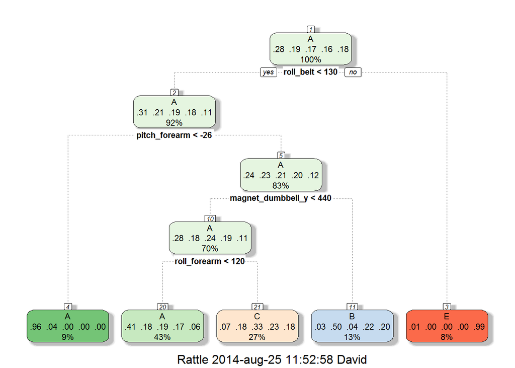

```r
fancyRpartPlot(modFit1$finalModel)
```

```r
predTest1<-predict(modFit1,dataTest[,-53])
# cross-validation
confusionMatrix(predTest1,dataTest$class)
```

```
## Confusion Matrix and Statistics
##
##           Reference
## Prediction    A    B    C    D    E
##          A 1490  492  464  408  150
##          B   26  377   33  170  134
##          C  121  246  508  366  302
##          D    0    0    0    0    0
##          E    4    0    0    0  472
##
## Overall Statistics
##
##                Accuracy : 0.494
##                  95% CI : (0.481, 0.507)
##     No Information Rate : 0.285
##     P-Value [Acc > NIR] : <2e-16
##
##                   Kappa : 0.338
##  Mcnemar's Test P-Value : NA
##
## Statistics by Class:
##
##                      Class: A Class: B Class: C Class: D Class: E
## Sensitivity             0.908   0.3381   0.5055    0.000   0.4461
## Specificity             0.633   0.9219   0.7825    1.000   0.9991
## Pos Pred Value          0.496   0.5095   0.3292      NaN   0.9916
## Neg Pred Value          0.945   0.8531   0.8822    0.836   0.8892
## Prevalence              0.285   0.1935   0.1744    0.164   0.1836
## Detection Rate          0.259   0.0654   0.0881    0.000   0.0819
## Detection Prevalence    0.521   0.1284   0.2677    0.000   0.0826
## Balanced Accuracy       0.770   0.6300   0.6440    0.500   0.7226
```

The tree plot already shows that “D” is not amongst the outcomes, so the model is not really fitting the data.

The confusion matrix also shows a lot of bad predictions

#### Random Forest

this model is chosen since it works very well for categorical data.

```r
library(randomForest)
modelFit2<-randomForest(x=dataTrain[,-53],y=dataTrain$classe,prox=TRUE)
modelFit2
```

```
##
## Call:
##  randomForest(x = dataTrain[, -53], y = dataTrain$classe, proximity = TRUE)
##                Type of random forest: classification
##                      Number of trees: 500
## No. of variables tried at each split: 7
##
##         OOB estimate of  error rate: 0.5%
## Confusion matrix:
##      A    B    C    D    E class.error
## A 3829    1    0    0    0   0.0002611
## B   12 2587    4    0    0   0.0061468
## C    0   17 2329    1    0   0.0076694
## D    0    0   21 2182    0   0.0095325
## E    0    0    3    8 2459   0.0044534
```

```r
modelFit2$importance[order(modelFit2$importance,decreasing=TRUE),]
```

```
##            roll_belt             yaw_belt        pitch_forearm
##               858.78               615.43               539.94
##    magnet_dumbbell_z           pitch_belt    magnet_dumbbell_y
##               519.97               473.36               468.79
##         roll_forearm    magnet_dumbbell_x     accel_dumbbell_y
##               414.81               335.58               287.69
##         accel_belt_z        roll_dumbbell        magnet_belt_z
##               282.04               281.62               266.79
##        magnet_belt_y     accel_dumbbell_z      accel_forearm_x
##               255.38               228.86               222.50
##             roll_arm         gyros_belt_z     magnet_forearm_z
##               218.62               214.77               196.58
## total_accel_dumbbell         yaw_dumbbell        magnet_belt_x
##               178.46               173.21               171.15
##         magnet_arm_x              yaw_arm          accel_arm_x
##               170.64               167.68               165.65
##      accel_forearm_z     gyros_dumbbell_y     accel_dumbbell_x
##               163.56               162.24               159.40
##     total_accel_belt     magnet_forearm_y         magnet_arm_y
##               159.36               158.56               151.14
##     magnet_forearm_x         magnet_arm_z          yaw_forearm
##               142.92               126.71               120.58
##            pitch_arm       pitch_dumbbell          accel_arm_y
##               118.95               115.70               108.05
##          gyros_arm_y      accel_forearm_y          gyros_arm_x
##                97.25                96.18                93.49
##     gyros_dumbbell_x      gyros_forearm_y          accel_arm_z
##                93.38                89.29                88.90
##         accel_belt_y         gyros_belt_y         accel_belt_x
##                87.19                84.34                81.21
##  total_accel_forearm         gyros_belt_x      total_accel_arm
##                76.55                68.90                66.08
##      gyros_forearm_z     gyros_dumbbell_z      gyros_forearm_x
##                62.10                58.47                55.69
##          gyros_arm_z
##                40.23
```

```r
predTest2<-predict(modelFit2,dataTest[,-53])
# cross-validation
confusionMatrix(predTest2,dataTest$class)
```

```
## Confusion Matrix and Statistics
##
##           Reference
## Prediction    A    B    C    D    E
##          A 1640    3    0    0    0
##          B    1 1111    7    0    0
##          C    0    1  996    9    0
##          D    0    0    2  935    6
##          E    0    0    0    0 1052
##
## Overall Statistics
##
##                Accuracy : 0.995
##                  95% CI : (0.993, 0.997)
##     No Information Rate : 0.285
##     P-Value [Acc > NIR] : <2e-16
##
##                   Kappa : 0.994
##  Mcnemar's Test P-Value : NA
##
## Statistics by Class:
##
##                      Class: A Class: B Class: C Class: D Class: E
## Sensitivity             0.999    0.996    0.991    0.990    0.994
## Specificity             0.999    0.998    0.998    0.998    1.000
## Pos Pred Value          0.998    0.993    0.990    0.992    1.000
## Neg Pred Value          1.000    0.999    0.998    0.998    0.999
## Prevalence              0.285    0.193    0.174    0.164    0.184
## Detection Rate          0.285    0.193    0.173    0.162    0.183
## Detection Prevalence    0.285    0.194    0.175    0.164    0.183
## Balanced Accuracy       0.999    0.997    0.994    0.994    0.997
```

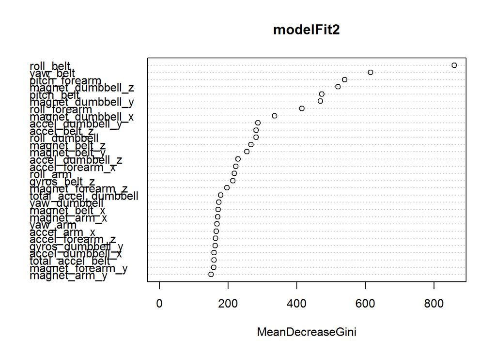

```r
varImpPlot(modelFit2,sort=TRUE)
```

Very good prediction. Out of sample Accuracy is very high (99.5%). The confusion matrix also keeps most of the values of the diagonal which shows the a good relation between predicted and actual values.

We will use this model for further testing on the test set.

#### Outcome of predicting the ‘classe’ of the test data with random forest

```r
predTest<-predict(modelFit2,test[,-53])
predTest
```

```
##  1  2  3  4  5  6  7  8  9 10 11 12 13 14 15 16 17 18 19 20
##  B  A  B  A  A  E  D  B  A  A  B  C  B  A  E  E  A  B  B  B
## Levels: A B C D E
```

```r
# pml_write_files = function(x){
#   n = length(x)
#   for(i in 1:n){
#     filename = paste0("problem_id_",i,".txt")
#     write.table(x[i],file=filename,quote=FALSE,row.names=FALSE,col.names=FALSE)
#   }
# }
#
# pml_write_files(predTest)
```

### Acknowledgements

http://groupware.les.inf.puc-rio.br/har#weight_lifting_exercises